# Linear Equations

## 1.1 Systems of Linear Equations

- Solving systems of linear equation is something you do in elementary algebra and linear algebra. Often times, you do algebraic manipulations such as subtracting terms from an equation.

$\begin{vmatrix} x + 2y + 3z = 8 \\ x + 3y + 3z = 10 \\ x + 2y + 4z = 9\end{vmatrix}$

- subtract equation *I* from equations *II* and *III*
  - $x - x + 3y - 2y + 3z - 3z = 10 - 8 \rightarrow y = 2 $
  - $x - x + 2y - 2y + 4z - 3z = 9 - 8 \rightarrow z = 1 $

$ \begin{vmatrix} x + 2y + 3z = 8 \\ 0 + y + 0 = 2 \\ 0 + 0 + z = 1\end{vmatrix} $

- subtract 2 *II* from *I* and subtract 3 *III* from I
  - $x + 2y - 2y + 3z = 8 -4 \rightarrow x + 3z = 4 $
  - $x + 3z -3z = 4 -3 \rightarrow x = 1$

$ \begin{vmatrix} x + 0 + 0 = 1 \\ 0 + y + 0 = 2 \\ 0 + 0 + z = 1\end{vmatrix} $

- Hence the final solution is $\begin{bmatrix} x \\ y \\ z \end{bmatrix} = \begin{bmatrix} 1 \\ 2 \\ 1 \end{bmatrix}$

## Geometric Interpretation

- The geometric interpretation of a system of equations such as the one above is that we have 3 planes intersecting at one point (1,2,1).

Three planes in space, intersecting at a point

[figure not shown]

Three planes having a line in common

[figure not shown]

Three planes with no common intersection

[figure not shown]

## Systems with No Solutions

- When the system is inconsistent there are no solutions. In other words, all the planes of the system of equations do not meet at a single point, line, or plane.
- For example, $\begin{vmatrix} x + 2y + 3z = 1 \\ x + 3y + 4z = 3 \\ x +4y + 5z = 4 \end{vmatrix}$
- Subtract equation I from equation II and subtract equation I from equation II.
  - $x - x + 3y - 2y + 4z -3z = 3 - 1 \longrightarrow y + z = 2$
  - $x - x + 4y - 2y + 5z -3z = 4 - 1 \longrightarrow y + z = \frac{3}{2}$
  - $\begin{vmatrix} x + 2y + 3z = 1 \\ 0 + y + z = 2 \\ 0 + y + z = \frac{3}{2} \end{vmatrix}$
    - Since y + z equates to different values, we can see that the system does not have any solution. However, if you want a more concrete piece of evidence subtract II from III
    - $\begin{vmatrix} x + 2y + 3z = 1 \\ 0 + y + z = 2 \\ 0 + 0 + 0 = -\frac{1}{2} \end{vmatrix}$
    - O cannot be equal -0.5; It is a contradiction.

## Systems with Infinitely Many Solutions

- When the system is consistent and there is a free variable, there are infinitely many solutions.
- For example, $\begin{vmatrix} x + 2y + 3z = 1 \\ 3x + 2y + z = 1 \\ 7x + 2y -3z = 1 \end{vmatrix}$
  - Subtract 3I from II and subtract 7I from III
    - $II - 3I \rightarrow 3x -3x + 2y -6y + z - 9z = 1 -3 \rightarrow 0 - 4y -8y = -2 \rightarrow y + 2z = \frac{1}{2}$
    - $III - 7I \rightarrow 7x -7x + 2y -14y - 3z - 21z = 1 -7 \rightarrow 0 - 12y -24z = -6 \rightarrow y + 2z = \frac{1}{2}$
- Since II and III are equivalent subtract II from III
  - Hence we get a free variable which in this case is z because x and y are pivot values or the first non-zero value of a row.
  - $\begin{vmatrix} x + 2y + 3z = 1 \\ 0 + y + 2z = \frac{1}{2} \\ 0 + 0 + 0 = 0 \end{vmatrix}$
  - $x = 1 -2y - 3z \\ y = \frac{1}{2} - 2z \\ z = t, \; f\!or \; t \in \mathbb{R} \\ \rightarrow x = 1 -2(\frac{1}{2} -2t) -3t = 1 - 1 + 4t -3t = t \\ y = \frac{1}{2} - 2t \\ z = t \\ \rightarrow \begin{bmatrix} x \\ y \\ z \end{bmatrix} = \begin{bmatrix} t \\ \frac{1}{2} -t \\ t \end{bmatrix}$
- As you can see above, the variable z is set to some arbitrary real scalar value or real number t since it is the free variable.

## 1.2 Matrices, Vectors, and Gauss-Jordan Elimination

- Matrices have $m$ rows and $n$ columns
- for instance let A be 3x2 matrix with real values as its entries.

$A = \begin{bmatrix} a_{11} & a_{12} \\ a_{21} & a_{22} \\ a_{31} & a_{32} \end{bmatrix}$ where $a_{ij} \in \mathbb{R}$

- A is called a square matrix if its number of rows and columns are the same.
  - let A be a $n \times n$ matrix where $n \in \mathbb{Z}^{non-negative} \\ A = \begin{bmatrix} a_{11} & a_{12} & \dots & a_{1 \; n-1} & a_{1n} \\ \vdots & \vdots & \vdots & \vdots & \vdots \\ \vdots & \vdots & \vdots & \vdots & \vdots \\ \vdots & \vdots & \vdots & \vdots & \vdots \\ a_{n-1 \; 1} & a_{n-1 \; 2} & \dots & a_{n-1 \; n-1} & a_{n-1 \; n} \\ a_{n1} & a_{n2} & \dots & a_{n \; n-1} & a_{nn} \end{bmatrix}$

$$$$

- A square matrix is called **diagonal** if all its entries above and below the main diagonal are zero. In other words, $a_{ij} = 0$ whenever $i \neq j$
  - Example let a be a 2x2 diagonal matrix with real entries $A = \begin{bmatrix} a_{11} & 0 \\ 0 & a_{22} \end{bmatrix}$, where $a_{ij} = 0$ if $i \neq j$

$$$$

- A square matrix A is called **upper triangular** if all its entries below the main diagonal are zero.
  - Example let a be a 3x3 upper triangular matrix with real entries $A = \begin{bmatrix} a_{11} & a_{12} & a_{13} \\ 0 & a_{22} & a_{23} \\ 0 & 0 & a_{33} \end{bmatrix}$, where $a_{ij} = 0$ whenever i exceeds j (i > j) or the index number of the row exceeds the index number of the column.

$$$$

- A square matrix is called **lower triangular** is all its entries above the main diagonal are zero.
  - Example let a be a 3x3 lower triangular matrix with real entries $A = \begin{bmatrix} a_{11} & 0 & 0 \\ a_{12} & a_{22} & 0 \\ a_{31} & a_{32} & a_{33} \end{bmatrix}$, where $a_{ij} = 0$ whenever j exceeds 1 or the index number of the column exceeds the index number of the row.
- A zero matrix is a matrix for which all entries are 0
  - Ex $A = \begin{bmatrix} 0 & 0 \\ 0 & 0 \end{bmatrix} \\ \\ B = \begin{bmatrix} 0 & 0 & 0 \\ 0 & 0 & 0\end{bmatrix} $

## Vectors and Vector Spaces

- A **column vector** is a matrix with only one column.
  - The set of all column vectors with n components is denoted by $\mathbb{R}^n$
  - $\mathbb{R}^n$ is a vector space
- A **row vector** is a matrix with only one row.
  - The set of all row vectors with n components is denoted by $\mathbb{R}^n$
  - $\mathbb{R}^n$ is a vector space

**Standard Representation of Vectors**

- $\vec{v} = \begin{bmatrix} x \\ y \end{bmatrix}$
  - In the Cartesian coordinate plane is an arrow or a direct line segment from the origin to the point (x, y), as shown in the figure below
  - This is the standard representation in $\mathbb{R}^2$

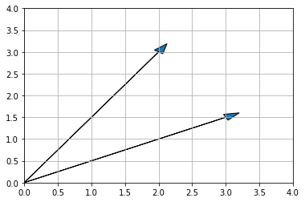

```python
import matplotlib.pyplot as plt
import numpy as np

v = np.array([2,3])

plt.arrow(0,0, v[0], v[1], head_width = 0.15 ) # this is the original vector
plt.arrow(0,0, v[0] + 1, v[1] - 1.5, head_width = 0.15 ) # this is the tranlated vector
plt.axis([0, 4, 0, 4])
plt.grid()
plt.show()
```

- $\vec{v} = \begin{bmatrix} x \\ y \\ z \end{bmatrix}$
  - In the 3D coordinate plane is an arrow or a direct line segment from the origin to the point (x, y, z), as shown in figure below. The vector in the figure below is $\vec{v} = \begin{bmatrix} 7 \\ 1 \\ 7 \end{bmatrix}$
  - This is the standard representation in $\mathbb{R}^3$

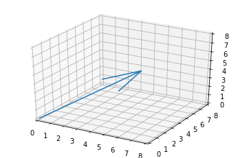

```python
from mpl_toolkits.mplot3d import Axes3D
fig = plt.figure()
ax = fig.add_subplot(111, projection='3d')
ax.quiver(0,0,0, 7,1, 7)
ax.set_xlim([0, 8])
ax.set_ylim([0, 8])
ax.set_zlim([0, 8])
plt.show()
```

**Types of elementary row operations**

- Divide a row by a non-zero scalar
- Subtract a multiple of a row from another row.
- Swap two rows

**Reduced row-echelon form**

**A matrix is in RREF if it satisfies all three conditions below**

1. If a row has nonzero entries, then the first nonzero entry is a 1, called the leading 1 (or pivot) in this row.
2. If a column contains a leading 1, then all the other entries in that column are 0
3. If a row contains a leading 1, then each row above it contains a leading 1 further to the left
- Ex The identity matrix denoted $I$ is in rref $I = \begin{bmatrix} 1 & 0 & 0 \\ 0 & 1 & 0 \\ 0 & 0 & 1 \end{bmatrix}$
- $A_1 = \begin{bmatrix} 2 & 0 & 0 \\ 0 & 1 & 0 \\ 0 & 0 & 1 \end{bmatrix}$ is not in rref because the first entry $a_{11}$ needs to be scaled by $\frac{1}{2}$ $$$$
- $A_1 = \begin{bmatrix} 1 & 0 & 0 \\ 0 & 0 & 1 \\ 0 & 1 & 1 \end{bmatrix}$ is not in rref because equation II (the second row) has to be subtracted from equation III ( the third row) and the third row must be swapped for the second row.

## 1.3 On Solutions of Linear Systems

**Number of solutions of a linear system**

## - A system of equation is said to be *consistent* if there is at least one solution; it is inconsistent if there are no solutions.

- **Theorem**
  - A linear system is inconsistent if and only if a contradiction such as $0 = c$, where $c \neq 0$ arises. Usually, when the RREF for a augmented matrix contains a row $\begin{bmatrix} 0 & 0 & \dots & 0 \vdots 1 \end{bmatrix}$
  - If a linear system is consistent, then it has either
    - Infinitely many solutions (if there is at least one free variable)
    - exactly one solution (if all columns have a pivot entry)
- Definition: **The rank of a matrix** is the number of leading ones in rref($A$), denoted rank($A$)

Ex

$I = \begin{bmatrix} 1 & 0 & 0 \\ 0 & 1 & 0 \\ 0 & 0 & 1 \end{bmatrix}$

```
- rank(I) = 3 because there is 1 leading ones at each row.
```

$A = \begin{bmatrix} 1 & 2 & 0 \\ 0 & 1 & 0 \\ 0 & 0 & 0 \end{bmatrix}$

```
- rank(A) = 2 because there are 2 leading ones in two rows.
```

## **Number of equations vs. number of unknowns**

1. If a linear system has exactly one solution, then there must be at least as many equations as there are variables ($m \le n$ with the notation from example 3).
   - $p \rightarrow q$, where p = a linear system has one solution and q = there must be at least as many equations as there are variables ($m \; (rows) \; \le \; n \; (columns))$;
1. (contrapositive of 1 )A linear system with fewer equations than unknowns ($n < m$) has either no solutions or infinitely many solutions.
   - ($\neg q \rightarrow \neg p$), where where p = a linear system has one solution and q = there must be at least as many equations as there are variables ($m \; (rows) \; \le \; n \; (columns)\;)$;

## **Systems of n equations in n variables**

- A linear system of n equations in nvariables has a unique solution if and only if the rank of its coefficient matrix $A$ is n

$$rref(A) = \begin{bmatrix} 1 & 0 & 0 & \dots & 0 \\ 0 & 1 & 0 & \dots & 0 \\ 0 & 0 & 1 & \dots & 0 \\ \vdots & \vdots & \vdots & \ddots & \vdots \\ 0 & 0 & 0 & \dots & 1\end{bmatrix}$$

## **Matrix Algebra**

**Algebraic rules for $A\vec{x}$**

- if A is an $n \times m$ matrix, $\vec{x}$ and $\vec{y}$ are vectors in $\mathbb{R}^m$, and k is a scalar, then
  - $A(\vec{x} + \vec{y}) = A\vec{x} + A\vec{y}$
  - $A(k\vec{x}) = k(A\vec{x})$
- **Theorem: Matrix for of a linear system**
  - We can write the linear system with augmented matrix $\left [ \begin{array}{ c : c} A & \vec{b} \end{array} \right ]$ in matrix form as $A\vec{x} = \vec{b}$
- Ex $$\left[ \begin{array}{ccc:c} x & 2 & 3 & 1 \\ 3 & 2 & 1 & 1 \\ 7 & 2 & -3 & 1 \end{array}\right] $$ can be written as $$ \begin{bmatrix} 1 & 2 & 3 \\ 3 & 2 & 1 \\ 7 & 2 & -3 \end{bmatrix}\vec{x} = \begin{bmatrix} 1 \\ 1 \\ 1 \end{bmatrix}$$, where
  $A = \begin{bmatrix} 1 & 2 & 3 \\ 3 & 2 & 1 \\ 7 & 2 & -3 \end{bmatrix}$ and $\vec{b} = \begin{bmatrix} 1 \\ 1 \\ 1 \end{bmatrix} $